# Home Air Quality Report for Participants

Prepared by: Lina Ang

Report generated on 2025-04-15

## Introduction

Household ID: **PC086**

This report provides an overview of the air quality in your home, focusing on PM<sub>2.5</sub> concentration levels. PM<sub>2.5</sub> concentration levels were determined based on the recorded particle count of fine particulate matter (PM<sub>2.5</sub>) during the monitoring period. Descriptive statistics and visualizations will be presented to illustrate the findings. According to the World Health Organization (WHO) air quality guidelines 2021, the 24-hour mean PM<sub>2.5</sub> concentration should not exceed 15 µg/m<sup>3</sup>, read more information on WHO air quality guidelines [here](https://www.who.int/news-room/feature-stories/detail/what-are-the-who-air-quality-guidelines).

The hourly average ambient (outdoor) PM<sub>2.5</sub> concentration levels are incorporated into the visualization of PM<sub>2.5</sub> air quality in your home. The historical ambient (outdoor) PM<sub>2.5</sub> data is sourced from the National Environmental Agency’s (NEA) API retrieved from [data.gov.sg](https://data.gov.sg/datasets/d_e1058d6974c877257e32048ab128ad83/view#tag/default/GET/pm25). NEA’s PM<sub>2.5</sub> data is split into five regions in Singapore—North, South, East, West, and Central—with readings available every hour. The readings from the region where your home is located are used to represent the outdoor air quality.

Please note that the reported PM<sub>2.5</sub> concentrations for your home are uncalibrated values.

The data covers the sampling period from **2025-03-21** to **2025-04-02**.

The mean PM<sub>2.5</sub> concentration level in your home during the sampling period was **above** the WHO recommended 24-hour limit of 15 µg/m<sup>3</sup>, indicating **poor** air quality.

| Mean | PM<sub>2.5</sub> concentration (µg/m<sup>3</sup>) Min | PM<sub>2.5</sub> concentration (µg/m<sup>3</sup>) Max |
| --- | --- | --- |
| 17.22 | 4.42 | 35.06 |

Note:  
Mean PM<sub>2.5</sub> < 15 µg/m<sup>3</sup> = good air quality; Mean PM<sub>2.5</sub> ≥ 15 µg/m<sup>3</sup> = poor air quality.

## Daily average PM<sub>2.5</sub> concentration (Home vs Outdoor)

This table provides the summary statistics for PM<sub>2.5</sub> concentration levels at your home for each day (daily average). The descriptive statistics include the mean, minimum, and maximum values of PM<sub>2.5</sub> concentration.

Descriptive Statistics for Daily PM<sub>2.5</sub> Concentration Levels at Home

| Date (Day) | PM<sub>2.5</sub> concentration (µg/m<sup>3</sup>) Mean | PM<sub>2.5</sub> concentration (µg/m<sup>3</sup>) Min | PM<sub>2.5</sub> concentration (µg/m<sup>3</sup>) Max |
| --- | --- | --- | --- |
| 2025-03-21 (Friday) | 16.68 | 15.17 | 20.56 |
| 2025-03-22 (Saturday) | 11.89 | 5.02 | 19.27 |
| 2025-03-23 (Sunday) | 4.42 | 0.00 | 16.15 |
| 2025-03-24 (Monday) | 9.91 | 1.64 | 18.82 |
| 2025-03-25 (Tuesday) | 25.40 | 9.08 | 47.55 |
| 2025-03-26 (Wednesday) | 35.06 | 24.16 | 60.91 |
| 2025-03-27 (Thursday) | 27.08 | 14.42 | 47.87 |
| 2025-03-28 (Friday) | 11.78 | 4.20 | 24.03 |
| 2025-03-29 (Saturday) | 20.57 | 11.40 | 27.62 |
| 2025-03-30 (Sunday) | 20.35 | 11.07 | 27.56 |
| 2025-03-31 (Monday) | 20.08 | 5.40 | 44.62 |
| 2025-04-01 (Tuesday) | 14.65 | 8.74 | 21.00 |
| 2025-04-02 (Wednesday) | 5.96 | 0.05 | 13.74 |

This plot displays the average PM<sub>2.5</sub> concentration levels at your home for each day, compared with the outdoor/ambient PM<sub>2.5</sub> concentration levels provided by NEA. The three highest PM<sub>2.5</sub> peaks at your home are highlighted on the plot.

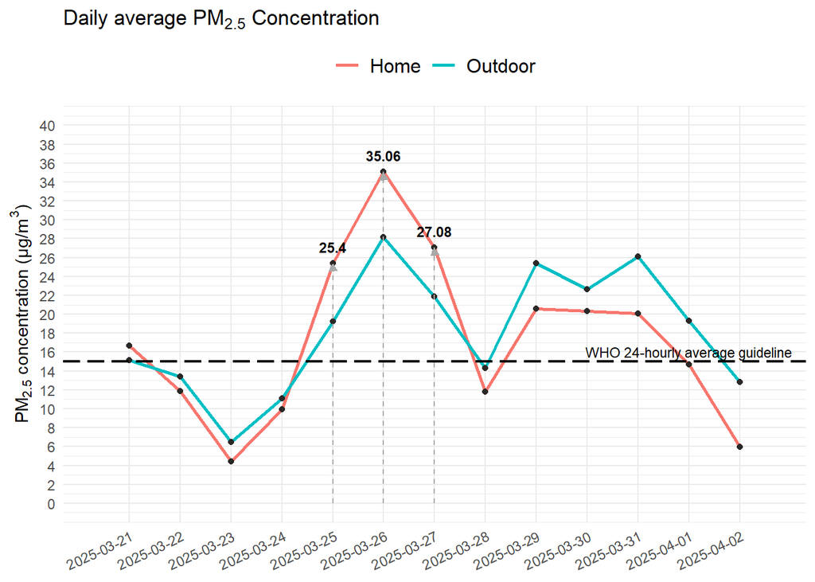

## Hourly average PM<sub>2.5</sub> concentration at Home (weekdays vs weekends)

This table presents the summary statistics for PM<sub>2.5</sub> concentration levels at your home, divided by weekdays (Monday to Friday) and weekends (Saturday and Sunday). The descriptive statistics include the mean, minimum, and maximum PM<sub>2.5</sub> concentration levels.

Descriptive Statistics for PM<sub>2.5</sub> Concentration Levels at Home

| Day | PM<sub>2.5</sub> concentration (µg/m<sup>3</sup>) Mean | PM<sub>2.5</sub> concentration (µg/m<sup>3</sup>) Min | PM<sub>2.5</sub> concentration (µg/m<sup>3</sup>) Max |
| --- | --- | --- | --- |
| Weekday | 19.40 | 0.05 | 60.91 |
| Weekend | 14.31 | 0.00 | 27.62 |

This plot shows the average PM<sub>2.5</sub> concentration levels for your home, separated by hour, for weekdays (Monday to Friday) and weekends (Saturday and Sunday). The top 3 highest PM<sub>2.5</sub> peaks are marked on the plot.

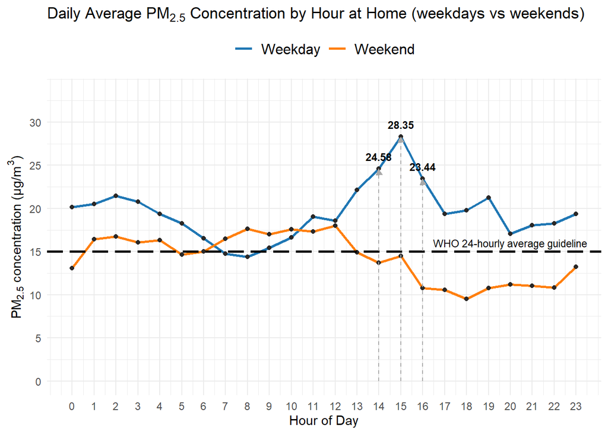

The following sections present the 24-hourly average values for each day of the week (Monday to Sunday).

## Monday

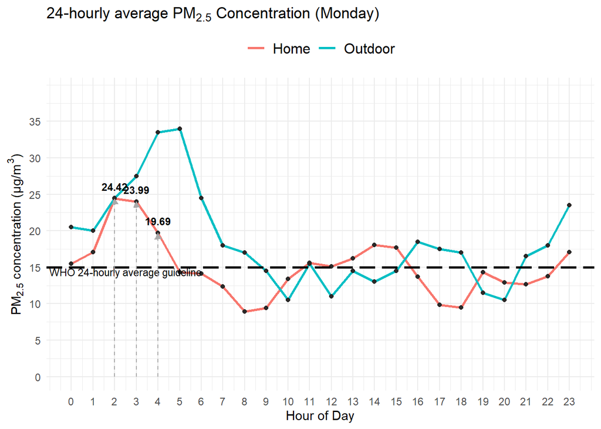

| Mean | PM<sub>2.5</sub> concentration (µg/m<sup>3</sup>) Min | PM<sub>2.5</sub> concentration (µg/m<sup>3</sup>) Max |
| --- | --- | --- |
| 14.99 | 8.94 | 24.42 |

## Tuesday

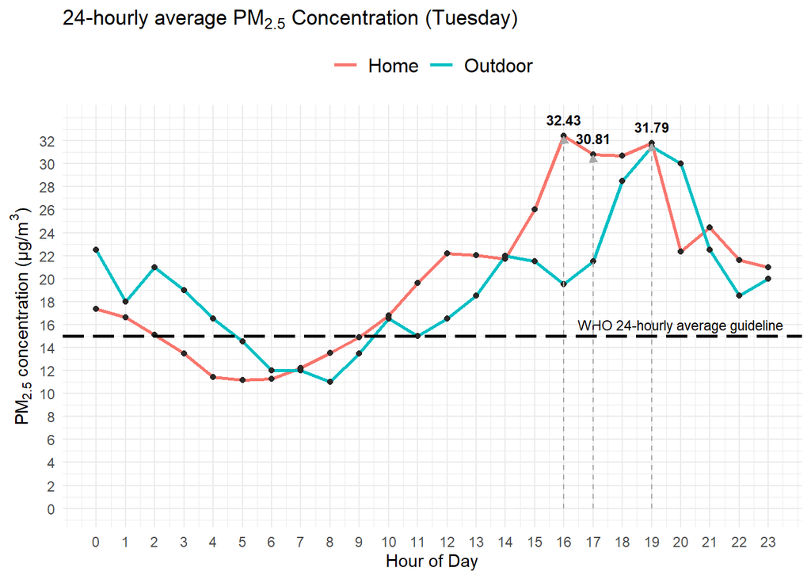

| Mean | PM<sub>2.5</sub> concentration (µg/m<sup>3</sup>) Min | PM<sub>2.5</sub> concentration (µg/m<sup>3</sup>) Max |
| --- | --- | --- |
| 20.03 | 11.15 | 32.43 |

## Wednesday

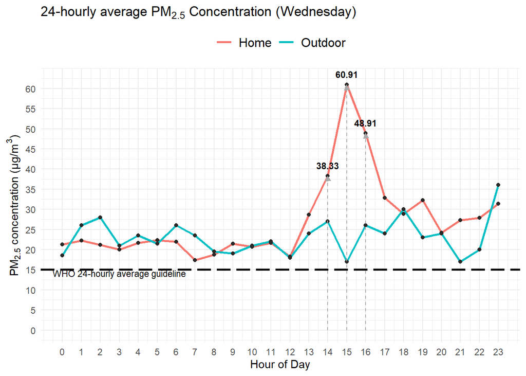

| Mean | PM<sub>2.5</sub> concentration (µg/m<sup>3</sup>) Min | PM<sub>2.5</sub> concentration (µg/m<sup>3</sup>) Max |
| --- | --- | --- |
| 27.09 | 17.37 | 60.91 |

## Thursday

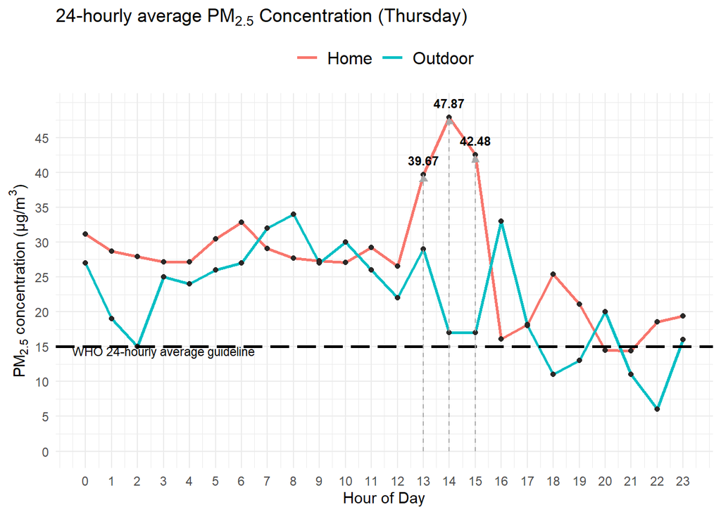

[output not shown]

## Friday

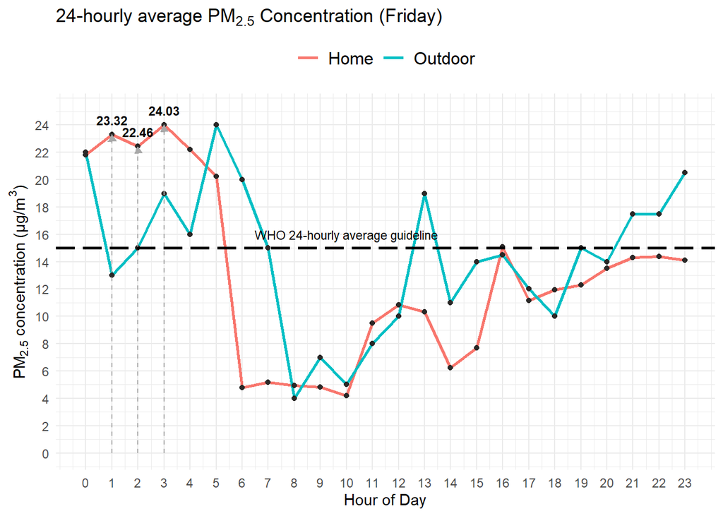

| Mean | PM<sub>2.5</sub> concentration (µg/m<sup>3</sup>) Min | PM<sub>2.5</sub> concentration (µg/m<sup>3</sup>) Max |
| --- | --- | --- |
| 12.89 | 4.2 | 24.03 |

## Saturday

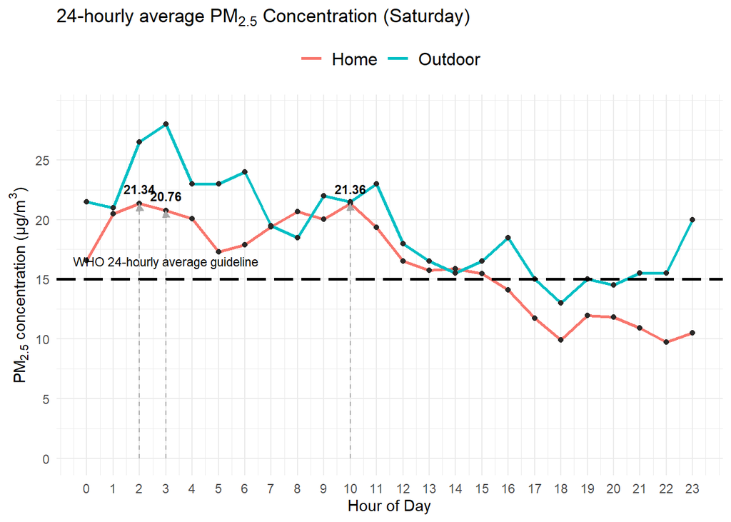

| Mean | PM<sub>2.5</sub> concentration (µg/m<sup>3</sup>) Min | PM<sub>2.5</sub> concentration (µg/m<sup>3</sup>) Max |
| --- | --- | --- |
| 16.23 | 9.72 | 21.36 |

## Sunday

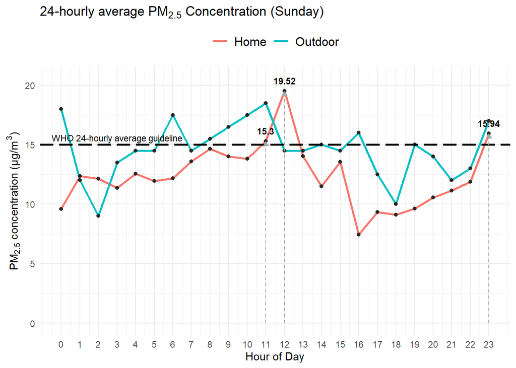

| Mean | PM<sub>2.5</sub> concentration (µg/m<sup>3</sup>) Min | PM<sub>2.5</sub> concentration (µg/m<sup>3</sup>) Max |
| --- | --- | --- |
| 12.38 | 7.42 | 19.52 |

## Contact information

The data and content in this report are copyrighted and may not be reused without permission. If you need more details, please email me at ephanli@nus.edu.sg.

End of Report©